# Association Rules I

Margaret Miró

21746 Data Mining 2022-23

## Association Rules

Association mining is commonly used to make product recommendations by identifying products that are frequently bought together. It is one of the key techniques used by large retailers to uncover associations between items by identifying relationships between the items that people buy.

There is a great R package called “arules” from Michael Hahsler who has implemented the algorithm in R.

```r
library(arules)
```

A rule is a notation that represents which item/s is frequently bought with what item/s. It has an LHS and an RHS part and can be represented as: $A \rightarrow B$. This means, the item/s in $B$ were frequently purchased along with items of $A$.

The “apriori()” function generates the most relevant set of rules from a given transaction data. It also shows the support, confidence and lift of those rules. These three measure can be used to decide the relative strength of the rules. So what do these terms mean?

- “support” is how many transactions support the condition.
  $$s(A \rightarrow B) = \frac{\sigma(A,B)}{|T|} = P(A \cup B)$$
- “confidence” is how confident the condition is.
  $$c(A \rightarrow B) = \frac{s(A \rightarrow B)}{s(A)} = \frac{P(A \cup B)}{P(A)}$$
- “lift” is how often the condition actually happened compared to the estimated chance for that to happen (expected value).
  $$lift(A \rightarrow B) = \frac{c(A \rightarrow B)}{s(B)} = \frac{P(A \cup B)}{P(A)\cdot P(B)}$$
  Lift is the factor by which, the co-occurrence of A and B exceeds the expected probability of A and B co-occurring, had they been independent. So, higher the lift, higher the chance of A and B occurring together.

### Groceries Data Set

Let’s play with the Groceries data that comes with the “arules” package. The file Groceries is public data of buying records in a grocery store. Each row corresponds to one transaction. Load the data.

```r
data(Groceries)
```

Groceries contains sales data from a local grocery store with 9835 transactions and 169 items (products sold). The summary shows some basic statistics of the data set.

```r
summary(Groceries)
```

```
## transactions as itemMatrix in sparse format with
##  9835 rows (elements/itemsets/transactions) and
##  169 columns (items) and a density of 0.02609146
##
## most frequent items:
##       whole milk other vegetables       rolls/buns             soda
##             2513             1903             1809             1715
##           yogurt          (Other)
##             1372            34055
##
## element (itemset/transaction) length distribution:
## sizes
##    1    2    3    4    5    6    7    8    9   10   11   12   13   14   15   16
## 2159 1643 1299 1005  855  645  545  438  350  246  182  117   78   77   55   46
##   17   18   19   20   21   22   23   24   26   27   28   29   32
##   29   14   14    9   11    4    6    1    1    1    1    3    1
##
##    Min. 1st Qu.  Median    Mean 3rd Qu.    Max.
##   1.000   2.000   3.000   4.409   6.000  32.000
##
## includes extended item information - examples:
##        labels  level2           level1
## 1 frankfurter sausage meat and sausage
## 2     sausage sausage meat and sausage
## 3  liver loaf sausage meat and sausage
```

The data set is rather sparse with a density just above 2.6%, “whole milk” is the most popular item and that the average transaction contains less than 5 items.

#### Exploring and preparing the Groceries data

Unlike with a dataframe, using “head(Groceries)” does not display the transaction items in the data. To view the transactions, use the “inspect()” function instead.

```r
inspect(Groceries[1:4, ]) # too many transactions, only look at the first 4
```

```
##     items
## [1] {citrus fruit,
##      semi-finished bread,
##      margarine,
##      ready soups}
## [2] {tropical fruit,
##      yogurt,
##      coffee}
## [3] {whole milk}
## [4] {pip fruit,
##      yogurt,
##      cream cheese ,
##      meat spreads}
```

By looking at the first row, we can say that ‘citrus fruit’, ‘semi-finished bread’, ‘margarine’ and ‘ready soups’ were bought together in a same transaction.

Since association mining deals with transactions, the data has to be converted to one of class transactions, made available in R through the “arules” package. This is a necessary step because the “apriori()” function only accepts transactions data of class transactions.

```r
class(Groceries)
```

```
## [1] "transactions"
## attr(,"package")
## [1] "arules"
```

If you have to read data from a file as a transactions data, use read.transactions(). For example, tdata <- read.transactions(“transactions_data.txt”, sep=").

If you already have your transactions stored as a dataframe, you could convert it to class transactions as follows: tData <- as (myDataFrame, “transactions”)

Transactions can also be visualized:

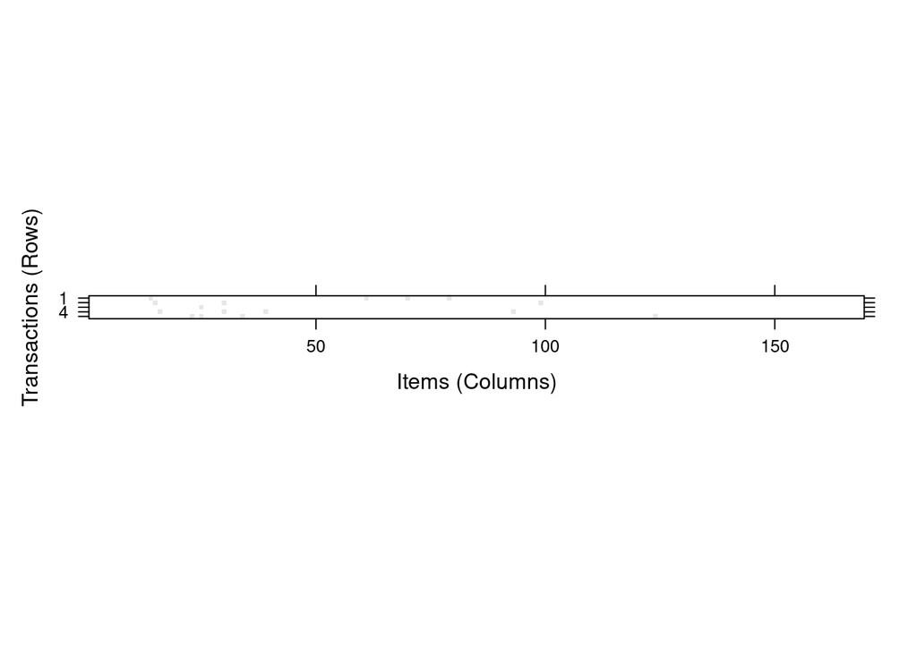

```r
image(Groceries[1:5]) # a visualization of the sparse matrix for the first five transactions
```

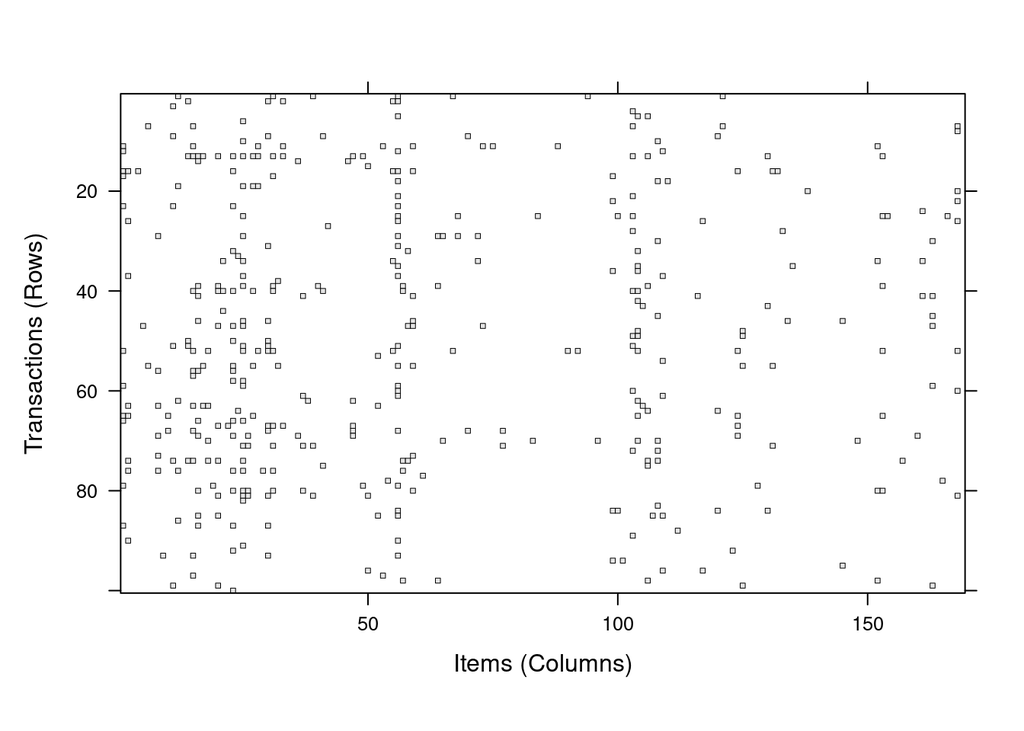

```r
image(sample(Groceries, 100)) # visualization of a random sample of 100 transactions
```

Different plots showing the frequency of the individual items can be created.

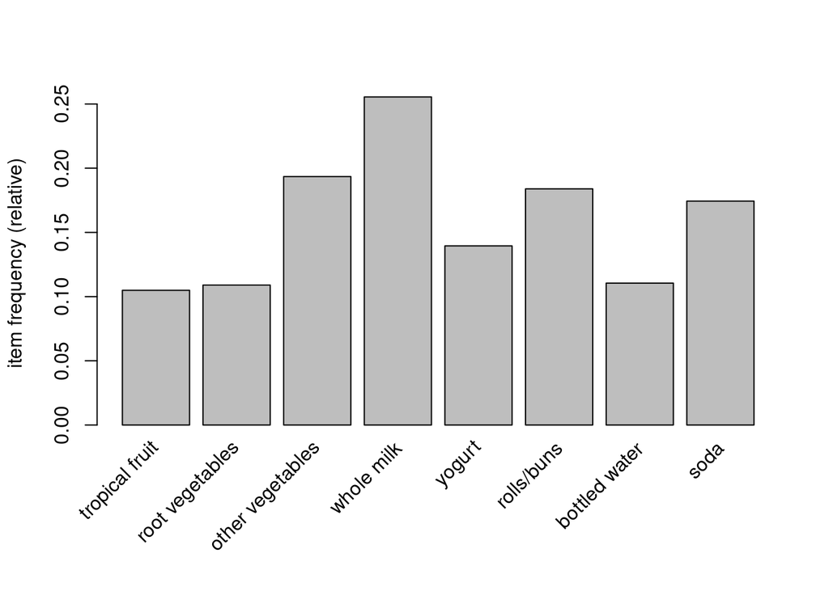

```r
itemFrequencyPlot(Groceries, support = 0.1) ## minimum support 0.1
```

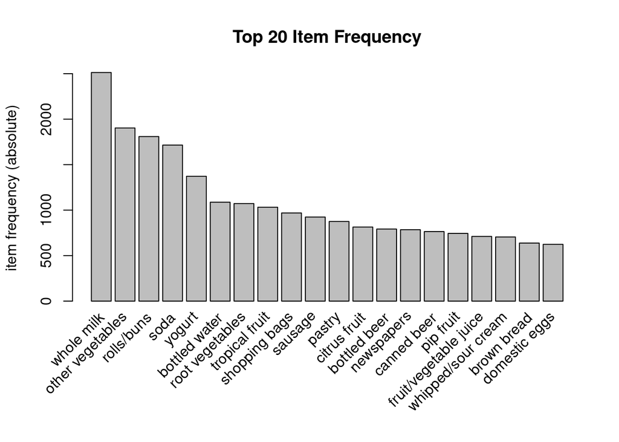

```r
itemFrequencyPlot(Groceries, topN = 20, type = "absolute", main = "Top 20 Item Frequency") ## plot of top 20 most frequent items
```

Here are couple more utility functions that are good to know:

```r
size(head(Groceries)) # number of items in each observation
```

```
## [1] 4 3 1 4 4 5
```

```r
LIST(head(Groceries, 3)) # convert 'transactions' to a list, note the LIST in CAPS
```

```
## [[1]]
## [1] "citrus fruit"        "semi-finished bread" "margarine"
## [4] "ready soups"
##
## [[2]]
## [1] "tropical fruit" "yogurt"         "coffee"
##
## [[3]]
## [1] "whole milk"
```

#### The most frequent items

The “eclat()” function takes in a transactions object and gives the most frequent items in the data based on the support you provide. The “maxlen” parameter defines the maximum number of items in each itemset of frequent items.

```r
frequentItems <- eclat(Groceries, parameter = list(support = 0.05)) # calculates support for frequent items
```

```
## Eclat
##
## parameter specification:
##  tidLists support minlen maxlen            target  ext
##     FALSE    0.05      1     10 frequent itemsets TRUE
##
## algorithmic control:
##  sparse sort verbose
##       7   -2    TRUE
##
## Absolute minimum support count: 491
##
## create itemset ...
## set transactions ...[169 item(s), 9835 transaction(s)] done [0.01s].
## sorting and recoding items ... [28 item(s)] done [0.00s].
## creating sparse bit matrix ... [28 row(s), 9835 column(s)] done [0.00s].
## writing  ... [31 set(s)] done [0.01s].
## Creating S4 object  ... done [0.00s].
```

```r
inspect(frequentItems)
```

```
##      items                          support    count
## [1]  {whole milk, yogurt}           0.05602440  551
## [2]  {whole milk, rolls/buns}       0.05663447  557
## [3]  {other vegetables, whole milk} 0.07483477  736
## [4]  {whole milk}                   0.25551601 2513
## [5]  {other vegetables}             0.19349263 1903
## [6]  {rolls/buns}                   0.18393493 1809
## [7]  {yogurt}                       0.13950178 1372
## [8]  {soda}                         0.17437722 1715
## [9]  {root vegetables}              0.10899847 1072
## [10] {tropical fruit}               0.10493137 1032
## [11] {bottled water}                0.11052364 1087
## [12] {sausage}                      0.09395018  924
## [13] {shopping bags}                0.09852567  969
## [14] {citrus fruit}                 0.08276563  814
```

[output cut: 17 more lines]

Let’s use smaller values for support to obtain a larger number of frequent itemsets.

```r
frequentItems2 <- eclat(Groceries, parameter = list(support = 0.01))
```

```
## Eclat
##
## parameter specification:
##  tidLists support minlen maxlen            target  ext
##     FALSE    0.01      1     10 frequent itemsets TRUE
##
## algorithmic control:
##  sparse sort verbose
##       7   -2    TRUE
##
## Absolute minimum support count: 98
##
## create itemset ...
## set transactions ...[169 item(s), 9835 transaction(s)] done [0.01s].
## sorting and recoding items ... [88 item(s)] done [0.00s].
## creating sparse bit matrix ... [88 row(s), 9835 column(s)] done [0.00s].
## writing  ... [333 set(s)] done [0.01s].
## Creating S4 object  ... done [0.00s].
```

```r
inspect(frequentItems2)
```

```
##       items                                                 support    count
## [1]   {whole milk, hard cheese}                             0.01006609   99
## [2]   {whole milk, butter milk}                             0.01159126  114
## [3]   {other vegetables, butter milk}                       0.01037112  102
## [4]   {ham, whole milk}                                     0.01148958  113
## [5]   {whole milk, sliced cheese}                           0.01077783  106
## [6]   {whole milk, oil}                                     0.01128622  111
## [7]   {onions, whole milk}                                  0.01209964  119
## [8]   {onions, other vegetables}                            0.01423488  140
## [9]   {berries, whole milk}                                 0.01179461  116
## [10]  {berries, other vegetables}                           0.01026945  101
## [11]  {berries, yogurt}                                     0.01057448  104
## [12]  {hamburger meat, whole milk}                          0.01474326  145
## [13]  {hamburger meat, other vegetables}                    0.01382816  136
## [14]  {whole milk, hygiene articles}                        0.01281139  126
```

[output cut: 319 more lines]

Let’s summarize all these frequent itemsets.

```r
summary(frequentItems2)
```

```
## set of 333 itemsets
##
## most frequent items:
##       whole milk other vegetables           yogurt       rolls/buns
##               71               63               39               36
##  root vegetables          (Other)
##               34              367
##
## element (itemset/transaction) length distribution:sizes
##   1   2   3
##  88 213  32
##
##    Min. 1st Qu.  Median    Mean 3rd Qu.    Max.
##   1.000   1.000   2.000   1.832   2.000   3.000
##
## summary of quality measures:
##     support            count
##  Min.   :0.01007   Min.   :  99.0
##  1st Qu.:0.01190   1st Qu.: 117.0
##  Median :0.01627   Median : 160.0
##  Mean   :0.02507   Mean   : 246.6
##  3rd Qu.:0.02603   3rd Qu.: 256.0
##  Max.   :0.25552   Max.   :2513.0
##
## includes transaction ID lists: FALSE
##
## mining info:
##       data ntransactions support
##  Groceries          9835    0.01
##                                                       call
##  eclat(data = Groceries, parameter = list(support = 0.01))
```

#### Mining the Rules (learning a model)

Let’s generate all rules using the Apriori algorithm:

```r
apriori(Groceries) ## for default values of the parameters
```

```
## Apriori
##
## Parameter specification:
##  confidence minval smax arem  aval originalSupport maxtime support minlen
##         0.8    0.1    1 none FALSE            TRUE       5     0.1      1
##  maxlen target  ext
##      10  rules TRUE
##
## Algorithmic control:
##  filter tree heap memopt load sort verbose
##     0.1 TRUE TRUE  FALSE TRUE    2    TRUE
##
## Absolute minimum support count: 983
##
## set item appearances ...[0 item(s)] done [0.00s].
## set transactions ...[169 item(s), 9835 transaction(s)] done [0.00s].
## sorting and recoding items ... [8 item(s)] done [0.00s].
## creating transaction tree ... done [0.00s].
## checking subsets of size 1 2 done [0.00s].
## writing ... [0 rule(s)] done [0.00s].
## creating S4 object  ... done [0.00s].
```

```
## set of 0 rules
```

The default settings result in zero rules learned. The default behavior is to mine rules with minimum support of 0.1, minimum confidence of 0.8, and maximum of 10 items per itemset (maxlen). To learn more about the parameters type ?apriori.

Going back to our problem. We need to set other support and confidence levels to learn rules.

**Note:** Apriori only creates rules with one item in the RHS (Consequent)! The default value for minlen is 1. This means that rules with only one item (i.e., an empty antecedent/LHS) like $\{ \} \rightarrow {beer}$ will be created. These rules mean that no matter what other items are involved, the item in the RHS will appear with the probability given by the rule’s confidence (which equals the support). To avoid these rules set minlen=2.

```r
Grules <- apriori(Groceries, parameter = list(supp = 0.01, conf = 0.5, minlen = 2))
```

```
## Apriori
##
## Parameter specification:
##  confidence minval smax arem  aval originalSupport maxtime support minlen
##         0.5    0.1    1 none FALSE            TRUE       5    0.01      2
##  maxlen target  ext
##      10  rules TRUE
##
## Algorithmic control:
##  filter tree heap memopt load sort verbose
##     0.1 TRUE TRUE  FALSE TRUE    2    TRUE
##
## Absolute minimum support count: 98
##
## set item appearances ...[0 item(s)] done [0.00s].
## set transactions ...[169 item(s), 9835 transaction(s)] done [0.00s].
## sorting and recoding items ... [88 item(s)] done [0.00s].
## creating transaction tree ... done [0.00s].
## checking subsets of size 1 2 3 4 done [0.00s].
## writing ... [15 rule(s)] done [0.00s].
## creating S4 object  ... done [0.00s].
```

We have obtained 15 rules, it’s a reasonable number to inspect. Let’s look at the rules.

```r
inspect(Grules)
```

```
##      lhs                                       rhs                support
## [1]  {curd, yogurt}                         => {whole milk}       0.01006609
## [2]  {other vegetables, butter}             => {whole milk}       0.01148958
## [3]  {other vegetables, domestic eggs}      => {whole milk}       0.01230300
## [4]  {yogurt, whipped/sour cream}           => {whole milk}       0.01087951
## [5]  {other vegetables, whipped/sour cream} => {whole milk}       0.01464159
## [6]  {pip fruit, other vegetables}          => {whole milk}       0.01352313
## [7]  {citrus fruit, root vegetables}        => {other vegetables} 0.01037112
## [8]  {tropical fruit, root vegetables}      => {other vegetables} 0.01230300
## [9]  {tropical fruit, root vegetables}      => {whole milk}       0.01199797
## [10] {tropical fruit, yogurt}               => {whole milk}       0.01514997
## [11] {root vegetables, yogurt}              => {other vegetables} 0.01291307
## [12] {root vegetables, yogurt}              => {whole milk}       0.01453991
## [13] {root vegetables, rolls/buns}          => {other vegetables} 0.01220132
## [14] {root vegetables, rolls/buns}          => {whole milk}       0.01270971
```

[output cut: 17 more lines]

Let’s list rules by confidence

```r
Grules_conf <- sort(Grules, by = "confidence", decreasing = TRUE) # 'high-confidence' rules.
inspect(head(Grules_conf)) # show the support, lift and confidence for all rules
```

```
##     lhs                                  rhs                support
## [1] {citrus fruit, root vegetables}   => {other vegetables} 0.01037112
## [2] {tropical fruit, root vegetables} => {other vegetables} 0.01230300
## [3] {curd, yogurt}                    => {whole milk}       0.01006609
## [4] {other vegetables, butter}        => {whole milk}       0.01148958
## [5] {tropical fruit, root vegetables} => {whole milk}       0.01199797
## [6] {root vegetables, yogurt}         => {whole milk}       0.01453991
##     confidence coverage   lift     count
## [1] 0.5862069  0.01769192 3.029608 102
## [2] 0.5845411  0.02104728 3.020999 121
## [3] 0.5823529  0.01728521 2.279125  99
## [4] 0.5736041  0.02003050 2.244885 113
## [5] 0.5700483  0.02104728 2.230969 118
## [6] 0.5629921  0.02582613 2.203354 143
```

Let’s list rules by lift

```r
Grules_lift <- sort(Grules, by = "lift", decreasing = TRUE) # 'high-lift' rules.
inspect(head(Grules_lift)) # show the support, lift and confidence for all rules
```

```
##     lhs                                  rhs                support
## [1] {citrus fruit, root vegetables}   => {other vegetables} 0.01037112
## [2] {tropical fruit, root vegetables} => {other vegetables} 0.01230300
## [3] {root vegetables, rolls/buns}     => {other vegetables} 0.01220132
## [4] {root vegetables, yogurt}         => {other vegetables} 0.01291307
## [5] {curd, yogurt}                    => {whole milk}       0.01006609
## [6] {other vegetables, butter}        => {whole milk}       0.01148958
##     confidence coverage   lift     count
## [1] 0.5862069  0.01769192 3.029608 102
## [2] 0.5845411  0.02104728 3.020999 121
## [3] 0.5020921  0.02430097 2.594890 120
## [4] 0.5000000  0.02582613 2.584078 127
## [5] 0.5823529  0.01728521 2.279125  99
## [6] 0.5736041  0.02003050 2.244885 113
```

#### Evaluating performance: summary of Groceries association rules

Adjusting the maxlen, support and confidence arguments in the apriori function we control the number of rules generated. You will have to adjust this based on the sparcesness of your data.

- To get “strong” rules, increase the value of “conf” parameter.
- To get “longer” rules, increase “maxlen”.

Let’s get some information on the rules.

```r
summary(Grules)
```

```
## set of 15 rules
##
## rule length distribution (lhs + rhs):sizes
##  3
## 15
##
##    Min. 1st Qu.  Median    Mean 3rd Qu.    Max.
##       3       3       3       3       3       3
##
## summary of quality measures:
##     support          confidence        coverage            lift
##  Min.   :0.01007   Min.   :0.5000   Min.   :0.01729   Min.   :1.984
##  1st Qu.:0.01174   1st Qu.:0.5151   1st Qu.:0.02089   1st Qu.:2.036
##  Median :0.01230   Median :0.5245   Median :0.02430   Median :2.203
##  Mean   :0.01316   Mean   :0.5411   Mean   :0.02454   Mean   :2.299
##  3rd Qu.:0.01403   3rd Qu.:0.5718   3rd Qu.:0.02598   3rd Qu.:2.432
##  Max.   :0.02227   Max.   :0.5862   Max.   :0.04342   Max.   :3.030
##      count
##  Min.   : 99.0
##  1st Qu.:115.5
##  Median :121.0
##  Mean   :129.4
##  3rd Qu.:138.0
##  Max.   :219.0
##
## mining info:
##       data ntransactions support confidence
##  Groceries          9835    0.01        0.5
##                                                                              call
##  apriori(data = Groceries, parameter = list(supp = 0.01, conf = 0.5, minlen = 2))
```

#### Improving performance

We can also find subsets of rules containing any yogurt items:

```r
yogurtrules <- subset(Grules, items %in% "yogurt")
inspect(yogurtrules)
```

```
##     lhs                             rhs                support    confidence
## [1] {curd, yogurt}               => {whole milk}       0.01006609 0.5823529
## [2] {yogurt, whipped/sour cream} => {whole milk}       0.01087951 0.5245098
## [3] {tropical fruit, yogurt}     => {whole milk}       0.01514997 0.5173611
## [4] {root vegetables, yogurt}    => {other vegetables} 0.01291307 0.5000000
## [5] {root vegetables, yogurt}    => {whole milk}       0.01453991 0.5629921
## [6] {other vegetables, yogurt}   => {whole milk}       0.02226741 0.5128806
##     coverage   lift     count
## [1] 0.01728521 2.279125  99
## [2] 0.02074225 2.052747 107
## [3] 0.02928317 2.024770 149
## [4] 0.02582613 2.584078 127
## [5] 0.02582613 2.203354 143
## [6] 0.04341637 2.007235 219
```

Let’s use other values for support and confidence and study the resulting rules.

```r
Grules2 <- apriori(Groceries, parameter = list(supp = 0.001, conf = 0.5))
```

```
## Apriori
##
## Parameter specification:
##  confidence minval smax arem  aval originalSupport maxtime support minlen
##         0.5    0.1    1 none FALSE            TRUE       5   0.001      1
##  maxlen target  ext
##      10  rules TRUE
##
## Algorithmic control:
##  filter tree heap memopt load sort verbose
##     0.1 TRUE TRUE  FALSE TRUE    2    TRUE
##
## Absolute minimum support count: 9
##
## set item appearances ...[0 item(s)] done [0.00s].
## set transactions ...[169 item(s), 9835 transaction(s)] done [0.00s].
## sorting and recoding items ... [157 item(s)] done [0.00s].
## creating transaction tree ... done [0.00s].
## checking subsets of size 1 2 3 4 5 6 done [0.01s].
## writing ... [5668 rule(s)] done [0.00s].
## creating S4 object  ... done [0.00s].
```

```r
summary(Grules2)
```

```
## set of 5668 rules
##
## rule length distribution (lhs + rhs):sizes
##    2    3    4    5    6
##   11 1461 3211  939   46
##
##    Min. 1st Qu.  Median    Mean 3rd Qu.    Max.
##    2.00    3.00    4.00    3.92    4.00    6.00
##
## summary of quality measures:
##     support           confidence        coverage             lift
##  Min.   :0.001017   Min.   :0.5000   Min.   :0.001017   Min.   : 1.957
##  1st Qu.:0.001118   1st Qu.:0.5455   1st Qu.:0.001729   1st Qu.: 2.464
##  Median :0.001322   Median :0.6000   Median :0.002135   Median : 2.899
##  Mean   :0.001668   Mean   :0.6250   Mean   :0.002788   Mean   : 3.262
##  3rd Qu.:0.001729   3rd Qu.:0.6842   3rd Qu.:0.002949   3rd Qu.: 3.691
##  Max.   :0.022267   Max.   :1.0000   Max.   :0.043416   Max.   :18.996
##      count
##  Min.   : 10.0
##  1st Qu.: 11.0
##  Median : 13.0
##  Mean   : 16.4
##  3rd Qu.: 17.0
##  Max.   :219.0
##
## mining info:
##       data ntransactions support confidence
##  Groceries          9835   0.001        0.5
##                                                                   call
##  apriori(data = Groceries, parameter = list(supp = 0.001, conf = 0.5))
```

Let’s list rules by confidence

```r
Grules2_conf <- sort(Grules2, by = "confidence", decreasing = TRUE) # 'high-confidence' rules.
inspect(head(Grules2_conf)) # show the support, lift and confidence for all rules
```

```
##     lhs                      rhs                    support confidence    coverage     lift count
## [1] {rice,
##      sugar}               => {whole milk}       0.001220132          1 0.001220132 3.913649    12
## [2] {canned fish,
##      hygiene articles}    => {whole milk}       0.001118454          1 0.001118454 3.913649    11
## [3] {root vegetables,
##      butter,
##      rice}                => {whole milk}       0.001016777          1 0.001016777 3.913649    10
## [4] {root vegetables,
##      whipped/sour cream,
##      flour}               => {whole milk}       0.001728521          1 0.001728521 3.913649    17
## [5] {butter,
##      soft cheese,
##      domestic eggs}       => {whole milk}       0.001016777          1 0.001016777 3.913649    10
## [6] {citrus fruit,
##      root vegetables,
##      soft cheese}         => {other vegetables} 0.001016777          1 0.001016777 5.168156    10
```

The rules with confidence of 1 imply that, whenever the LHS item was purchased, the RHS item was also purchased 100% of the time.

Let’s list rules by lift

```r
Grules2_lift <- sort(Grules2, by = "lift", decreasing = TRUE) # 'high-lift' rules.
inspect(head(Grules2_lift)) # show the support, lift and confidence for all rules
```

```
##     lhs                         rhs                  support confidence    coverage     lift count
## [1] {Instant food products,
##      soda}                   => {hamburger meat} 0.001220132  0.6315789 0.001931876 18.99565    12
## [2] {soda,
##      popcorn}                => {salty snack}    0.001220132  0.6315789 0.001931876 16.69779    12
## [3] {flour,
##      baking powder}          => {sugar}          0.001016777  0.5555556 0.001830198 16.40807    10
## [4] {ham,
##      processed cheese}       => {white bread}    0.001931876  0.6333333 0.003050330 15.04549    19
## [5] {whole milk,
##      Instant food products}  => {hamburger meat} 0.001525165  0.5000000 0.003050330 15.03823    15
## [6] {other vegetables,
##      curd,
##      yogurt,
##      whipped/sour cream}     => {cream cheese }  0.001016777  0.5882353 0.001728521 14.83409    10
```

A rule with a lift of 18 implies that, the items in LHS and RHS are 18 times more likely to be purchased together compared to the purchases when they are assumed to be unrelated.

#### To find what factors influenced purchase of product X

To better understand the patterns that led to the purchase of ‘whole milk’, let’s find out what customers had purchased before buying ‘Whole Milk’. We are looking for rules with “whole milk” in the RHS.

```r
rules1 <- apriori(data = Groceries, parameter = list(supp = 0.001, conf = 0.5, minlen = 2), appearance = list(default = "lhs", rhs = "whole milk"), control = list(verbose = F)) # get rules that lead to buying 'whole milk'
rules1_conf <- sort(rules1, by = "confidence", decreasing = TRUE) # 'high-confidence' rules.
inspect(head(rules1_conf))
```

```
##     lhs                      rhs              support confidence    coverage     lift count
## [1] {rice,
##      sugar}               => {whole milk} 0.001220132          1 0.001220132 3.913649    12
## [2] {canned fish,
##      hygiene articles}    => {whole milk} 0.001118454          1 0.001118454 3.913649    11
## [3] {root vegetables,
##      butter,
##      rice}                => {whole milk} 0.001016777          1 0.001016777 3.913649    10
## [4] {root vegetables,
##      whipped/sour cream,
##      flour}               => {whole milk} 0.001728521          1 0.001728521 3.913649    17
## [5] {butter,
##      soft cheese,
##      domestic eggs}       => {whole milk} 0.001016777          1 0.001016777 3.913649    10
## [6] {pip fruit,
##      butter,
##      hygiene articles}    => {whole milk} 0.001016777          1 0.001016777 3.913649    10
```

#### To find out what products were purchased after/along with product X

The is a case to find out the Customers who bought ‘Whole Milk’ also bought …. In the equation, ‘whole milk’ is in LHS (left hand side).

```r
rules2 <- apriori(data = Groceries, parameter = list(supp = 0.001, conf = 0.15, minlen = 2), appearance = list(default = "rhs", lhs = "whole milk"), control = list(verbose = F)) # those who bought 'milk' also bought...
rules2_conf <- sort(rules2, by = "confidence", decreasing = TRUE) # 'high-confidence' rules.
inspect(head(rules2_conf))
```

```
##     lhs             rhs                support    confidence coverage lift
## [1] {whole milk} => {other vegetables} 0.07483477 0.2928770  0.255516 1.5136341
## [2] {whole milk} => {rolls/buns}       0.05663447 0.2216474  0.255516 1.2050318
## [3] {whole milk} => {yogurt}           0.05602440 0.2192598  0.255516 1.5717351
## [4] {whole milk} => {root vegetables}  0.04890696 0.1914047  0.255516 1.7560310
## [5] {whole milk} => {tropical fruit}   0.04229792 0.1655392  0.255516 1.5775950
## [6] {whole milk} => {soda}             0.04006101 0.1567847  0.255516 0.8991124
##     count
## [1] 736
## [2] 557
## [3] 551
## [4] 481
## [5] 416
## [6] 394
```

One drawback with this is, you will get only 1 item on the RHS, irrespective of the support, confidence or minlen parameters.

#### Rule Visualization

Let’s go back to Grules2. It is clear that going through all the 5668 rules manually is not a viable option. We will introduce different visualization techniques implemented in “arulesViz”.

```r
library(arulesViz)
```

The default method for “plot()” for association rules in “arulesViz” is a scatter plot using support and confidence on the axes. In addition a third measure (default: lift) is used as the color (gray level) of the points. A color key is provided to the right of the plot.

```
## To reduce overplotting, jitter is added! Use jitter = 0 to prevent jitter.
```

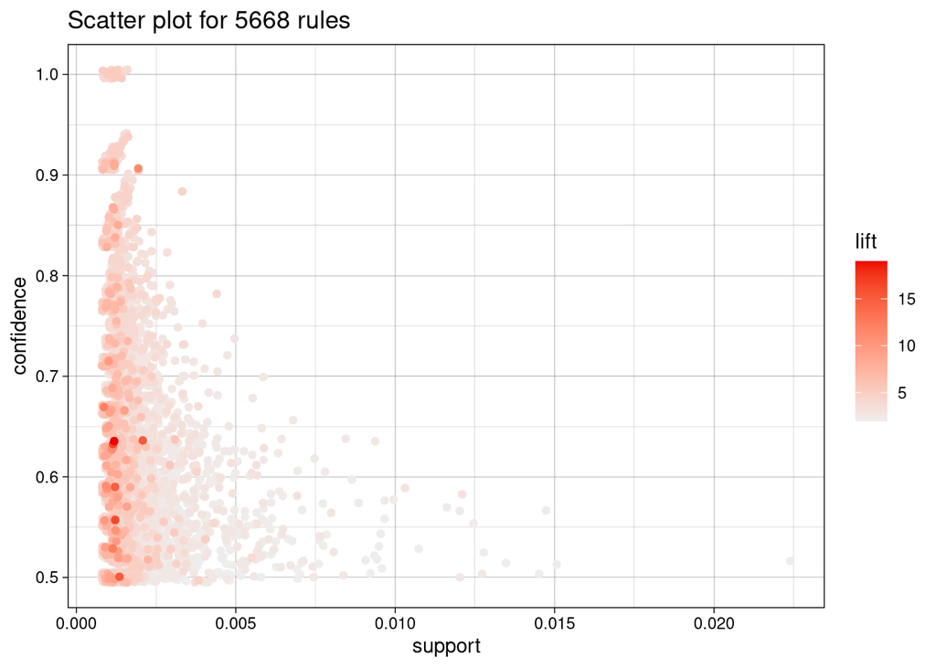

```r
plot(Grules2)
```

We can see that rules with high lift have typically a relatively low support. The most interesting rules reside on the support/confidence border.

The two-key plot has support and confidence for the x and y-axes and the color of the points is used to indicate the number of items contained in the rule, the “order.” Two-key plots can be produced by:

```
## To reduce overplotting, jitter is added! Use jitter = 0 to prevent jitter.
```

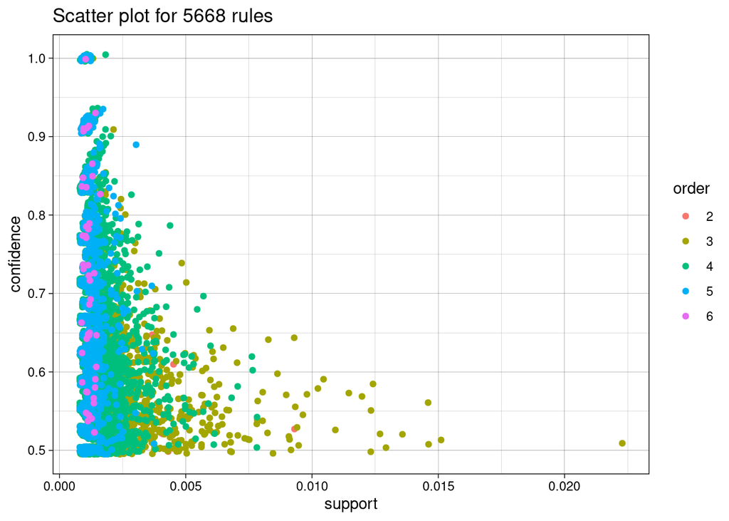

```r
plot(Grules2, method = "two-key plot")
```

From the plot it is clear that order and support have a very strong inverse relationship, which is a known fact for association rules.

Other graphs visualize association rules using vertices and edges where vertices annodated with item labels represent items, and itemsets or rules are represented as a second set of vertices. Items are connected with itemsets/rules using arrows. For rules arrows pointing from items to rule vertices indicate LHS items and an arrow from a rule to an item indicates the RHS. Interest measures are typically added to the plot by using color or size of the vertices representing the itemsets/rules.

The matrix visualization with grouped antecedents for the set of 5668 rules mined earlier can be easily created by

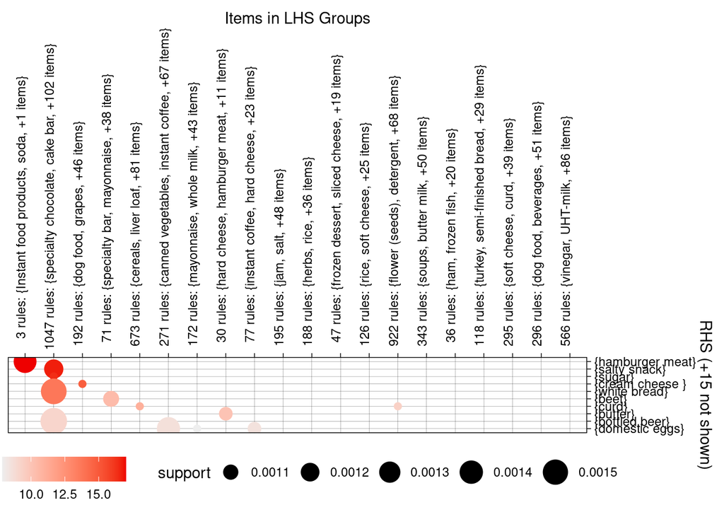

```r
plot(Grules2, method = "grouped")
```

Graph-based visualization offers a very clear representation of rules but they tend to easily become cluttered and thus are only viable for very small sets of rules. For the following plots we select the 10 rules with the highest lift.

```r
subrules <- head(Grules2, n = 10, by = "lift")
```

The following plot represents items and rules as vertices connecting them with directed edges. This representation focuses on how the rules are composed of individual items and shows which rules share items.

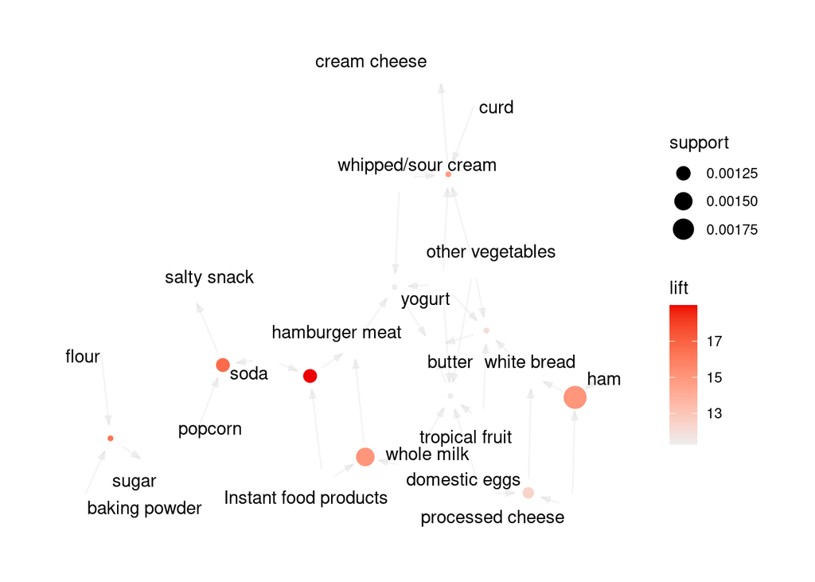

```r
plot(subrules, method = "graph")
```

To visualize the grouped matrix we use a balloon plot with antecedent groups as columns and consequent’s as rows. The color of the balloons represent the lift and the size of the balloon shows support. Furthermore, the columns and rows in the plot are reordered in such a way that the the most interesting group is placed in the top left corner. (Lift is decreasing from left to right.)

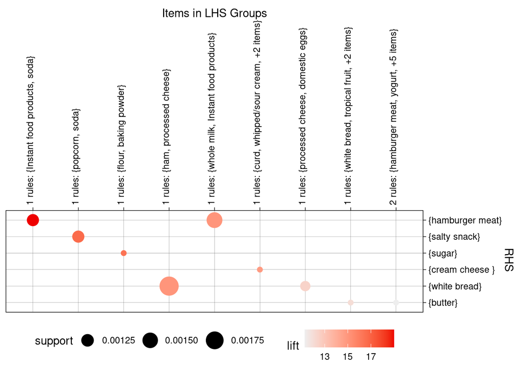

```r
plot(subrules, method = "grouped")
```